# EDS 222: Homework 1

Author

Emma Bea Mitchell

Published

Invalid Date

```r
library(tidyverse)
library(dplyr)
```

## Background

*(The case study in this exercise is based on reality, but does not include actual observational data.)*

In this exercise we will look at a case study concerning air quality in South Asia. The World Health Organization estimates that air pollution kills an estimated seven million people per year, due to its effects on the cardiovascular and respiratory systems. Out of the 40 most polluted cities in the world, South Asia is home to 37, and Pakistan was ranked to contain the second most air pollution in the world in 2020 (IQAIR, 2020). In 2019, Lahore, Pakistan was the 12th most polluted city in the world, exposing a population of 11.1 million people to increased mortality and morbidity risks.

In this exercise, you are given two datasets from Lahore, Pakistan and are asked to compare the two different data collection strategies from this city. These data are:

- Crowd-sourced data from air quality monitors located in people’s homes. These data are voluntarily collected by individual households who choose to install a monitor in their home and upload their data for public access.
- Official government data from monitors installed by government officials at selected locations across Lahore. There have been reports that government officials strategically locate monitors in locations with cleaner air in order to mitigate domestic and international pressure to clean up the air.

**Note**

All data for EDS 222 will be stored on the Taylor server, in the shared `/courses/eds-222/data/` directory. Please see material from EDS 214 on how to access and retrieve data from Taylor. These data are small; all compute can be handled locally. Thanks to Bren PhD student Fatiq Nadeem for assembling these data!

In answering the following questions, please consider the lecture content from class on sampling strategies, as well as the material in Chapter 2 of [*Introduction to Modern Statistics*](https://openintro-ims.netlify.app/data-design). Include in your submission your version of this file “`eds-222-hw1.qmd`” and the rendered HTML output, each containing complete answers to all questions *as well as the associated code*. Questions with answers unsupported by the code will be marked incomplete. Showing your work this way will help you develop the habit of creating reproducible code.

## Assessment

### Question 1

Load the data from each source and label it as `crowdsourced` and `govt` accordingly. For example:

```r
crowdsourced <- readRDS(file.path("data", "airpol-PK-crowdsourced.RDS"))
govt <- readRDS(file.path("data", "airpol-PK-govt.RDS"))
```

**Warning**

There’s an implicit assumption about file organization in the code above. What is it? How can you make the code work?

**It makes the assumption that you have a folder in your repository called data. I made this work easily by just creating that folder and putting my data in it**

1. These dataframes have one row per pollution observation. How many pollution records are in each dataset?

```r
print(nrow(crowdsourced))
```

```
[1] 5488
```

```r
print(nrow(govt))
```

```
[1] 1960
```

**The crowdsourced dataframe has 5488 pollution observations. The govt dataframe has 1960 pollution observations**

2. Each monitor is located at a unique latitude and longitude location. How many unique monitors are in each dataset?

```r
unique_crowd <- crowdsourced |>
  mutate(group_id = cur_group_id(),
         .by = longitude, latitude)
print(n_distinct(unique_crowd$group_id))
```

```
[1] 14
```

```r
unique_govt <- govt |>
  mutate(group_id = cur_group_id(),
         .by = latitude,longitude)
print(n_distinct(unique_govt$group_id))
```

```
[1] 4
```

**Tip**

`group_by(longitude,latitude)` and `cur_group_id()` in `dplyr` will help in creating a unique identifier for each (longitude, latitude) pair.

### Question 2

The goal of pollution monitoring in Lahore is to measure the average pollution conditions across the city.

1. What is the *population* in this setting? Please be precise

**in the crowdsourced dataset the population is Lahore’s air quality in the entire city for the entire timeframe from November 2018 to November 2019**

2. What are the *samples* in this setting? Please be precise.

**The samples are the actual air quality monitors throughout the city from November 2018 to November 2019. These are meant to represent the city collectively, because it is impossible to measure air quality in every single square inch of the city. One sample is the crowd sourced data and another is the government data. Different methodologies make these separate samples**

3. These samples were not randomly collected from across locations in Lahore. Given the sampling approaches described above, discuss possible biases that may enter when we use these samples to construct estimates of population parameters.

**The government has a bias when collecting their data. They want the city’s air to seem cleaner than it is. Therefore they pick specific places with better air quality to sample from. This becomes very clear when looking at the plot later on. It is also possible that the locations of the volunteered data are biased (maybe the volunteers wanted to test their air quality because they lived in areas with worse air), although this bias is clearly not as strong as the governmental data collection’s.**

### Question 3

1. For both the government data and the crowd-sourced data, report the sample mean, sample minimum, and sample maximum value of PM 2.5 (measured in $\mu g/m^3$).

   ```r
   print(mean(crowdsourced$PM))
   ```

   ```
   [1] 70.2008
   ```

   ```r
   print(min(crowdsourced$PM))
   ```

   ```
   [1] 20
   ```

   ```r
   print(max(crowdsourced$PM))
   ```

   ```
   [1] 120
   ```

   ```r
   print(mean(govt$PM))
   ```

   ```
   [1] 39.64694
   ```

   ```r
   print(min(govt$PM))
   ```

   ```
   [1] 15
   ```

   ```r
   print(max(govt$PM))
   ```

   ```
   [1] 65
   ```

mean of crowdsourced PM 2.5 is 70.2008 $\mu g/m^3$

minimum of crowdsourced PM 2.5 is 20 $\mu g/m^3$

max of crowdsourced PM 2.5 is 120 $\mu g/m^3$

mean of govt PM 2.5 is 39.64694 $\mu g/m^3$

minimum of govt PM 2.5 is 15 $\mu g/m^3$

maximum of govt PM 2.5 is 65 $\mu g/m^3$

2. Discuss any key differences that you see between these two samples

**The PM for the crowd sourced data is consistently higher than the govt data in mean, min, and max values**

3. Are the differences in mean pollution as expected, given what we know about the sampling strategies?

**Yes it is expected, because the government chose spots specifically with better air quality. It makes sense that the mean pollution would be much lower than the crowd sourced data. Crowd sourced data also has some bias, and it is possible that the volunteers’ had bias when collecting their samples. For example, volunteers could be collecting samples in areas where air quality was worse because people in those areas would be more incentivized to get samples. That could mean that their sample data was overall higher**

### Question 4

Use the location of the air pollution stations for both of the sampling strategies to generate a map showing locations of each observation. Color the two samples with different colors to highlight how each sample obtains measurements from different parts of the city.

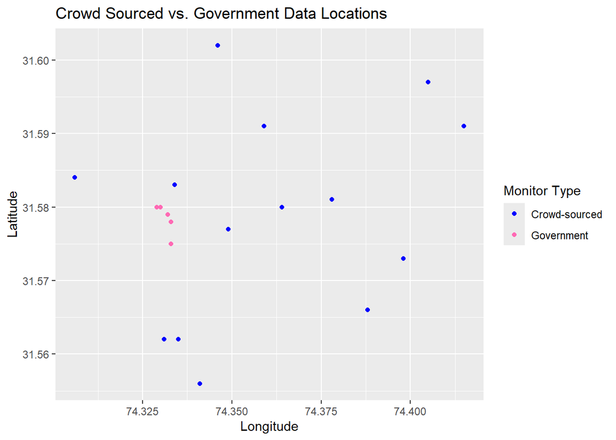

```r
plot_area <- ggplot(data = crowdsourced) +
  geom_point(aes(x = longitude, y = latitude, color = "Crowd-sourced")) +
  geom_point(data = govt, aes(x = longitude, y = latitude, color = "Government")) +
  labs(
    x = "Longitude",
    y = "Latitude",
    title = "Crowd Sourced vs. Government Data Locations"
  ) +
  scale_color_manual("Monitor Type", values = c("Crowd-sourced" = "blue", "Government" = "hotpink"))

print(plot_area)
```

**Tip**

`longitude` indicates location in the *x*-direction, while `latitude` indicates location in the *y*-direction. With `ggplot2` this should be nothing fancy. We’ll do more spatial data in `R` later in the course.

### Question 5

The local newspaper in Pakistan, *Dawn*, claims that the government is misreporting the air pollution levels in Lahore. Do the locations of monitors in question 4, relative to crowd-sourced monitors, suggest anything about a possible political bias?

**Yes it does suggest political bias because the government data is coming from a very limited area. The crowd sourced data has a much wider range in area. It is clear that the government’s data collection is not random. Crowd sourced data is also slightly biased because it still doesn’t have data from every part of the city**

### Question 6

Given the recent corruption in air quality reporting, the Prime Minister of Pakistan has hired an independent body of environmental data scientists to create an unbiased estimate of the mean PM 2.5 across Lahore using some combination of both government stations and crowd sourced observations.

NASA’s satellite data indicates that the average PM across Lahore is 89.2 $\mu g/m^3$. Since this is the most objective estimate of population-level PM 2.5 available, your goal is to match this mean as closely as possible by creating a new ground-level monitoring sample that draws on both the government and crowd-sourced samples.

#### Question 6.1

First, generate a *random sample* of size $n=1000$ air pollution records by (i) pooling observations across the government and the crowd-sourced data; and (ii) drawing observations at random from this pooled sample.

```r
govt <- govt |>
  mutate(source = "govt")
crowdsourced <- crowdsourced |>
  mutate(source = "crowdsourced")
set.seed(4321)
binded <- bind_rows(crowdsourced,govt)
rand_samp <- sample_n(binded, 1000)
print(rand_samp)
```

```
# A tibble: 1,000 × 5
   date          PM longitude latitude source
   <date>     <dbl>     <dbl>    <dbl> <chr>
 1 2019-01-11    32      74.3     31.6 govt
 2 2019-08-08    84      74.3     31.6 crowdsourced
 3 2018-12-16    75      74.4     31.6 crowdsourced
 4 2019-03-13    87      74.3     31.6 crowdsourced
 5 2019-02-12    56      74.4     31.6 crowdsourced
 6 2018-12-02    56      74.4     31.6 crowdsourced
 7 2019-03-21    53      74.3     31.6 crowdsourced
 8 2019-07-09    35      74.3     31.6 crowdsourced
 9 2019-03-25    23      74.4     31.6 crowdsourced
10 2019-09-18    64      74.3     31.6 govt
# ℹ 990 more rows
```

```r
print(mean(rand_samp$PM))
```

```
[1] 62.59
```

```r
print(min(rand_samp$PM))
```

```
[1] 15
```

```r
print(max(rand_samp$PM))
```

```
[1] 120
```

```r
print(dim(rand_samp))
```

```
[1] 1000    5
```

```r
kableExtra::kable(rand_samp |>
                    group_by(source) |>
                    count())
```

| source | n |
| --- | --- |
| crowdsourced | 728 |
| govt | 272 |

The mean of the random sample is 62.59, which is less than the crowd sourced data, but much more than the government data. The random sampling is definitely closer as a whole to the true NASA estimate than the original government sample was.

**Tip**

`bind_rows()` may be helpful.

Second, create a *stratified random sample*. Do so by (i) stratifying your pooled data-set into strata of 0.01 degrees of latitude, and (ii) randomly sampling 200 air pollution observations from each stratum.

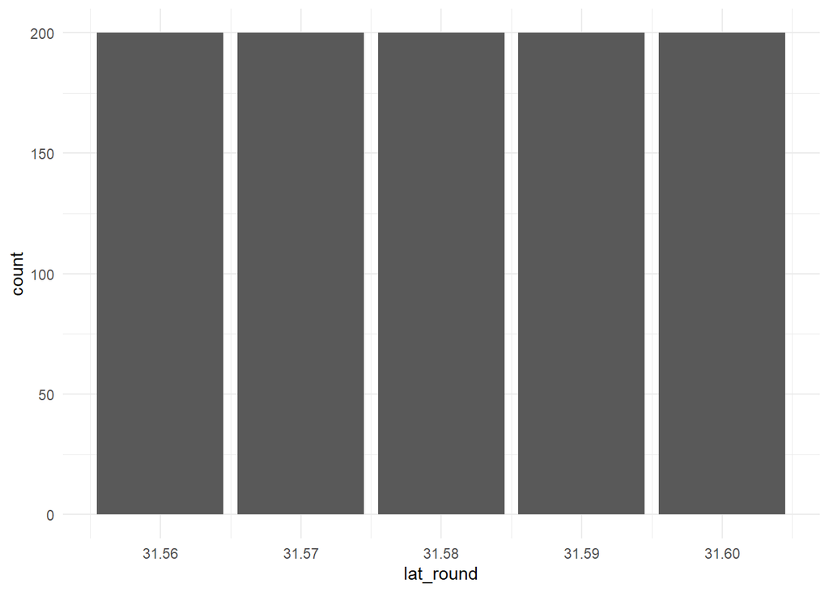

```r
round_bound <- binded |>
  mutate(lat_round = round(latitude, digits = 2))

strata_bound <- round_bound |>
  slice_sample(n = 200, replace = FALSE, by = lat_round)

strata_plot <- ggplot(strata_bound) +
  geom_bar(aes(x = lat_round)) +
  theme_minimal()

print(strata_plot)
```

```r
print(mean(strata_bound$PM))
```

```
[1] 66.6
```

```r
print(dim(strata_bound))
```

```
[1] 1000    6
```

#### Question 6.2

Compare estimated means of PM 2.5 for each sampling strategy to the NASA estimate of 89.2 $\mu g/m^3$. Which sample seems to match the satellite data best? What would you recommend the Prime Minister do? Does your proposed sampling strategy rely more on government or on crowd-sourced data? Why might that be the case?

The random sample mean is 62.59 $\mu g/m^3$

NASA estimate mean 89.2 $\mu g/m^3$